# Part I - Ford GoBike System Analysis

## Introduction

> This [dataset](https://docs.google.com/document/d/e/2PACX-1vQmkX4iOT6Rcrin42vslquX2_wQCjIa_hbwD0xmxrERPSOJYDtpNc_3wwK_p9_KpOsfA6QVyEHdxxq7/pub?embedded=True) includes a 2019 information about individual rides made in a bike-sharing system covering the greater San Francisco Bay area. Details such as the total duration of each subscriber's (or customer's) trip is located alongside the location where the trip started and where the trip ended.

> The dataset is a single csv file which will be assessed, cleaned and analyzed

## Preliminary Wrangling

In this section, the data will be visually and programmatically assessed to have an understanding of the data. Issues arising from this assessment will then be cleaned/wrangled before analysis and visualization is carried out.  
After this, the structure and features of the dataset will be evaluated and discussed.

### Assessment of Dataset

> Let us view the data and describe its properties. But first things first, we import our packages and data

```python
# import all packages and set plots to be embedded inline
import numpy as np
import pandas as pd
import matplotlib.pyplot as plt
import seaborn as sns
from pandas.api.types import CategoricalDtype
import datetime as dt
pd.options.mode.chained_assignment = None  # default='warn'

%matplotlib inline
```

```python
# import and load the dataset into a DataFrame
df = pd.read_csv('fordgobike.csv')
```

```python
df.head()
```

|  | duration_sec | start_time | end_time | start_station_id | start_station_name | start_station_latitude | start_station_longitude | end_station_id | end_station_name | end_station_latitude | end_station_longitude | bike_id | user_type | member_birth_year | member_gender | bike_share_for_all_trip |
| --- | --- | --- | --- | --- | --- | --- | --- | --- | --- | --- | --- | --- | --- | --- | --- | --- |
| 0 | 52185 | 2019-02-28 17:32:10.1450 | 2019-03-01 08:01:55.9750 | 21.0 | Montgomery St BART Station (Market St at 2nd St) | 37.789625 | -122.400811 | 13.0 | Commercial St at Montgomery St | 37.794231 | -122.402923 | 4902 | Customer | 1984.0 | Male | No |
| 1 | 42521 | 2019-02-28 18:53:21.7890 | 2019-03-01 06:42:03.0560 | 23.0 | The Embarcadero at Steuart St | 37.791464 | -122.391034 | 81.0 | Berry St at 4th St | 37.775880 | -122.393170 | 2535 | Customer | NaN | NaN | No |
| 2 | 61854 | 2019-02-28 12:13:13.2180 | 2019-03-01 05:24:08.1460 | 86.0 | Market St at Dolores St | 37.769305 | -122.426826 | 3.0 | Powell St BART Station (Market St at 4th St) | 37.786375 | -122.404904 | 5905 | Customer | 1972.0 | Male | No |
| 3 | 36490 | 2019-02-28 17:54:26.0100 | 2019-03-01 04:02:36.8420 | 375.0 | Grove St at Masonic Ave | 37.774836 | -122.446546 | 70.0 | Central Ave at Fell St | 37.773311 | -122.444293 | 6638 | Subscriber | 1989.0 | Other | No |
| 4 | 1585 | 2019-02-28 23:54:18.5490 | 2019-03-01 00:20:44.0740 | 7.0 | Frank H Ogawa Plaza | 37.804562 | -122.271738 | 222.0 | 10th Ave at E 15th St | 37.792714 | -122.248780 | 4898 | Subscriber | 1974.0 | Male | Yes |

```python
df.info()
```

```
<class 'pandas.core.frame.DataFrame'>
RangeIndex: 183412 entries, 0 to 183411
Data columns (total 16 columns):
duration_sec               183412 non-null int64
start_time                 183412 non-null object
end_time                   183412 non-null object
start_station_id           183215 non-null float64
start_station_name         183215 non-null object
start_station_latitude     183412 non-null float64
start_station_longitude    183412 non-null float64
end_station_id             183215 non-null float64
end_station_name           183215 non-null object
end_station_latitude       183412 non-null float64
end_station_longitude      183412 non-null float64
bike_id                    183412 non-null int64
user_type                  183412 non-null object
member_birth_year          175147 non-null float64
member_gender              175147 non-null object
bike_share_for_all_trip    183412 non-null object
dtypes: float64(7), int64(2), object(7)
memory usage: 22.4+ MB
```

```python
df.describe()
```

|  | duration_sec | start_station_id | start_station_latitude | start_station_longitude | end_station_id | end_station_latitude | end_station_longitude | bike_id | member_birth_year |
| --- | --- | --- | --- | --- | --- | --- | --- | --- | --- |
| count | 183412.000000 | 183215.000000 | 183412.000000 | 183412.000000 | 183215.000000 | 183412.000000 | 183412.000000 | 183412.000000 | 175147.000000 |
| mean | 726.078435 | 138.590427 | 37.771223 | -122.352664 | 136.249123 | 37.771427 | -122.352250 | 4472.906375 | 1984.806437 |
| std | 1794.389780 | 111.778864 | 0.099581 | 0.117097 | 111.515131 | 0.099490 | 0.116673 | 1664.383394 | 10.116689 |
| min | 61.000000 | 3.000000 | 37.317298 | -122.453704 | 3.000000 | 37.317298 | -122.453704 | 11.000000 | 1878.000000 |
| 25% | 325.000000 | 47.000000 | 37.770083 | -122.412408 | 44.000000 | 37.770407 | -122.411726 | 3777.000000 | 1980.000000 |
| 50% | 514.000000 | 104.000000 | 37.780760 | -122.398285 | 100.000000 | 37.781010 | -122.398279 | 4958.000000 | 1987.000000 |
| 75% | 796.000000 | 239.000000 | 37.797280 | -122.286533 | 235.000000 | 37.797320 | -122.288045 | 5502.000000 | 1992.000000 |
| max | 85444.000000 | 398.000000 | 37.880222 | -121.874119 | 398.000000 | 37.880222 | -121.874119 | 6645.000000 | 2001.000000 |

```python
df.shape
```

```
(183412, 16)
```

```python
df.sample(5)
```

|  | duration_sec | start_time | end_time | start_station_id | start_station_name | start_station_latitude | start_station_longitude | end_station_id | end_station_name | end_station_latitude | end_station_longitude | bike_id | user_type | member_birth_year | member_gender | bike_share_for_all_trip |
| --- | --- | --- | --- | --- | --- | --- | --- | --- | --- | --- | --- | --- | --- | --- | --- | --- |
| 152291 | 1162 | 2019-02-06 15:53:53.6520 | 2019-02-06 16:13:16.5070 | 246.0 | Berkeley Civic Center | 37.869060 | -122.270556 | 351.0 | 10th St at University Ave | 37.869060 | -122.293400 | 5123 | Customer | NaN | NaN | No |
| 159219 | 237 | 2019-02-05 18:14:35.4250 | 2019-02-05 18:18:33.0490 | 180.0 | Telegraph Ave at 23rd St | 37.812678 | -122.268773 | 337.0 | Webster St at 19th St | 37.806970 | -122.266588 | 4525 | Subscriber | 1971.0 | Male | No |
| 63428 | 327 | 2019-02-20 15:02:22.8820 | 2019-02-20 15:07:50.0760 | 98.0 | Valencia St at 16th St | 37.765052 | -122.421866 | 88.0 | 11th St at Bryant St | 37.770030 | -122.411726 | 6585 | Subscriber | 1975.0 | Male | No |
| 178698 | 703 | 2019-02-01 16:31:18.7740 | 2019-02-01 16:43:01.8140 | 182.0 | 19th Street BART Station | 37.809013 | -122.268247 | 194.0 | Lakeshore Ave at Trestle Glen Rd | 37.811081 | -122.243268 | 4560 | Subscriber | 1970.0 | Female | No |
| 39478 | 595 | 2019-02-23 08:50:48.3960 | 2019-02-23 09:00:43.9190 | 251.0 | California St at University Ave | 37.870555 | -122.279720 | 265.0 | Ninth St at Parker St | 37.858868 | -122.291209 | 4594 | Subscriber | 1988.0 | Female | No |

```python
# What year is captured in the dataset

df.start_time.str[:4].unique()
```

```
array(['2019'], dtype=object)
```

```python
# Check if the column names are descriptive enough

df.columns.tolist()
```

```
['duration_sec',
 'start_time',
 'end_time',
 'start_station_id',
 'start_station_name',
 'start_station_latitude',
 'start_station_longitude',
 'end_station_id',
 'end_station_name',
 'end_station_latitude',
 'end_station_longitude',
 'bike_id',
 'user_type',
 'member_birth_year',
 'member_gender',
 'bike_share_for_all_trip']
```

```python
# Check columns with null values

df.isnull().sum()
```

```
duration_sec                  0
start_time                    0
end_time                      0
start_station_id            197
start_station_name          197
start_station_latitude        0
start_station_longitude       0
end_station_id              197
end_station_name            197
end_station_latitude          0
end_station_longitude         0
bike_id                       0
user_type                     0
member_birth_year          8265
member_gender              8265
bike_share_for_all_trip       0
dtype: int64
```

```python
# Check for duplicated rows

df.duplicated().sum()
```

```
0
```

```python
# Investigate where member_birth_year and member_gender is null
df[df['member_birth_year'].isnull()].sample(5)
```

|  | duration_sec | start_time | end_time | start_station_id | start_station_name | start_station_latitude | start_station_longitude | end_station_id | end_station_name | end_station_latitude | end_station_longitude | bike_id | user_type | member_birth_year | member_gender | bike_share_for_all_trip |
| --- | --- | --- | --- | --- | --- | --- | --- | --- | --- | --- | --- | --- | --- | --- | --- | --- |
| 115830 | 259 | 2019-02-12 08:26:16.7950 | 2019-02-12 08:30:36.5590 | 345.0 | Hubbell St at 16th St | 37.766483 | -122.398279 | 67.0 | San Francisco Caltrain Station 2 (Townsend St... | 37.776639 | -122.395526 | 4637 | Subscriber | NaN | NaN | No |
| 30143 | 241 | 2019-02-24 21:54:25.2850 | 2019-02-24 21:58:27.2750 | 240.0 | Haste St at Telegraph Ave | 37.866043 | -122.258804 | 266.0 | Parker St at Fulton St | 37.862464 | -122.264791 | 6432 | Subscriber | NaN | NaN | No |
| 179999 | 189 | 2019-02-01 12:21:59.3700 | 2019-02-01 12:25:08.5570 | 355.0 | 23rd St at Tennessee St | 37.755367 | -122.388795 | 126.0 | Esprit Park | 37.761634 | -122.390648 | 5405 | Subscriber | NaN | NaN | No |
| 131358 | 292 | 2019-02-09 13:12:48.2410 | 2019-02-09 13:17:40.6370 | 30.0 | San Francisco Caltrain (Townsend St at 4th St) | 37.776598 | -122.395282 | 90.0 | Townsend St at 7th St | 37.771058 | -122.402717 | 232 | Customer | NaN | NaN | No |
| 23481 | 405 | 2019-02-25 20:16:42.3960 | 2019-02-25 20:23:28.0190 | 101.0 | 15th St at Potrero Ave | 37.767079 | -122.407359 | 124.0 | 19th St at Florida St | 37.760447 | -122.410807 | 4613 | Customer | NaN | NaN | No |

```python
df[df['member_gender'].isnull()].sample(5)
```

|  | duration_sec | start_time | end_time | start_station_id | start_station_name | start_station_latitude | start_station_longitude | end_station_id | end_station_name | end_station_latitude | end_station_longitude | bike_id | user_type | member_birth_year | member_gender | bike_share_for_all_trip |
| --- | --- | --- | --- | --- | --- | --- | --- | --- | --- | --- | --- | --- | --- | --- | --- | --- |
| 13525 | 904 | 2019-02-27 15:43:43.8930 | 2019-02-27 15:58:48.0370 | 61.0 | Howard St at 8th St | 37.776513 | -122.411306 | 13.0 | Commercial St at Montgomery St | 37.794231 | -122.402923 | 4928 | Subscriber | NaN | NaN | No |
| 44128 | 591 | 2019-02-22 15:25:50.6440 | 2019-02-22 15:35:42.5000 | 66.0 | 3rd St at Townsend St | 37.778742 | -122.392741 | 3.0 | Powell St BART Station (Market St at 4th St) | 37.786375 | -122.404904 | 4455 | Subscriber | NaN | NaN | No |
| 2730 | 233 | 2019-02-28 17:54:40.7140 | 2019-02-28 17:58:34.0870 | 22.0 | Howard St at Beale St | 37.789756 | -122.394643 | 284.0 | Yerba Buena Center for the Arts (Howard St at ... | 37.784872 | -122.400876 | 333 | Subscriber | NaN | NaN | No |
| 21540 | 532 | 2019-02-26 09:06:52.6970 | 2019-02-26 09:15:45.5020 | 118.0 | Eureka Valley Recreation Center | 37.759177 | -122.436943 | 122.0 | 19th St at Mission St | 37.760299 | -122.418892 | 6081 | Customer | NaN | NaN | No |
| 71971 | 518 | 2019-02-19 17:02:22.4060 | 2019-02-19 17:11:00.6290 | 44.0 | Civic Center/UN Plaza BART Station (Market St ... | 37.781074 | -122.411738 | 22.0 | Howard St at Beale St | 37.789756 | -122.394643 | 5958 | Subscriber | NaN | NaN | No |

```python
# Investigate where start_station_id is null

df[df.start_station_id.isnull()].sample(5)
```

|  | duration_sec | start_time | end_time | start_station_id | start_station_name | start_station_latitude | start_station_longitude | end_station_id | end_station_name | end_station_latitude | end_station_longitude | bike_id | user_type | member_birth_year | member_gender | bike_share_for_all_trip |
| --- | --- | --- | --- | --- | --- | --- | --- | --- | --- | --- | --- | --- | --- | --- | --- | --- |
| 132593 | 439 | 2019-02-08 23:52:25.8470 | 2019-02-08 23:59:44.9270 | NaN | NaN | 37.42 | -121.95 | NaN | NaN | 37.41 | -121.94 | 4162 | Customer | 1981.0 | Male | No |
| 30726 | 2447 | 2019-02-24 18:04:43.5300 | 2019-02-24 18:45:31.4660 | NaN | NaN | 37.41 | -121.95 | NaN | NaN | 37.40 | -121.94 | 4141 | Subscriber | 1977.0 | Male | No |
| 176154 | 1447 | 2019-02-02 12:03:04.5440 | 2019-02-02 12:27:12.2670 | NaN | NaN | 37.40 | -121.93 | NaN | NaN | 37.40 | -121.93 | 4249 | Customer | 1984.0 | Male | No |
| 17908 | 393 | 2019-02-26 20:11:35.0800 | 2019-02-26 20:18:08.6700 | NaN | NaN | 37.40 | -121.94 | NaN | NaN | 37.40 | -121.93 | 4250 | Subscriber | 1990.0 | Male | No |
| 47802 | 232 | 2019-02-22 08:33:14.0300 | 2019-02-22 08:37:06.8300 | NaN | NaN | 37.41 | -121.96 | NaN | NaN | 37.41 | -121.95 | 4283 | Subscriber | 1977.0 | Male | No |

#### Observations from the Assessment

1. Data has enough samples for analysis with 183,412 rows and 16 columns.
2. Only 2019 data is captured in the data.
3. Column names are clearly stated and descriptive enough.
4. Some columns contain null values
5. There is no duplicated row
6. Having investigated samples of the data with NULL values, we can ignore the null rows. The `member_birth_year` and `member_gender` columns will be useful in understanding the demographics of the bike riders.
7. The `start_station_id` is a crucial part of our analysis as the data will probably give a wrong insight where the column ahs null values. NULL values in this column will be removed.

### Cleaning of the Dataset

> The next step following identifying issues in the dataset is doing the clean-up

#### Fill rows where `member_birth_year` and `member_gender` columns are NULL

```python
df['member_birth_year'].fillna(0, inplace = True)
df['member_gender'].fillna('Other', inplace = True)
```

```python
df.info()
```

```
<class 'pandas.core.frame.DataFrame'>
RangeIndex: 183412 entries, 0 to 183411
Data columns (total 16 columns):
duration_sec               183412 non-null int64
start_time                 183412 non-null object
end_time                   183412 non-null object
start_station_id           183215 non-null float64
start_station_name         183215 non-null object
start_station_latitude     183412 non-null float64
start_station_longitude    183412 non-null float64
end_station_id             183215 non-null float64
end_station_name           183215 non-null object
end_station_latitude       183412 non-null float64
end_station_longitude      183412 non-null float64
bike_id                    183412 non-null int64
user_type                  183412 non-null object
member_birth_year          183412 non-null float64
member_gender              183412 non-null object
bike_share_for_all_trip    183412 non-null object
dtypes: float64(7), int64(2), object(7)
memory usage: 22.4+ MB
```

#### Add `members_age` column

```python
# Add an additional column for age of members
# This will later help in understanding the age distribution of respondents
df['member_age'] = 2019 - df[df['member_birth_year'] != 0]['member_birth_year']
```

```python
# Fill null values, and convert column data type to int
df['member_age'].fillna(0, inplace = True)
df['member_age'] = df['member_age'].astype(int)
```

#### Add `duration_mins` column

```python
# Add an additional column for duration in minutes
df['duration_mins'] = df['duration_sec']/60
```

```python
# Fill null values, and convert column data type to int
df['member_age'].fillna(0, inplace = True)
df['member_age'] = df['member_age'].astype(int)
```

```python
df['start_time'].head()
```

```
0    2019-02-28 17:32:10.1450
1    2019-02-28 18:53:21.7890
2    2019-02-28 12:13:13.2180
3    2019-02-28 17:54:26.0100
4    2019-02-28 23:54:18.5490
Name: start_time, dtype: object
```

```python
df['start_time'].str[:19].head()
```

```
0    2019-02-28 17:32:10
1    2019-02-28 18:53:21
2    2019-02-28 12:13:13
3    2019-02-28 17:54:26
4    2019-02-28 23:54:18
Name: start_time, dtype: object
```

#### Add `start_hour` column

```python
# Convert 'start_time' to datetime data type
df['start_time'] = pd.to_datetime(df['start_time'].str[:19], format='%Y-%m-%d %H:%M:%S')

# Add an additional column for 'start_hour'
df['start_hour'] = df['start_time'].dt.strftime('%H')

# Order the start_hour
order_hour = ['01', '02', '03', '04', '05', '06', '07', '08', '09', '10', '11', '12',
         '13', '14', '15', '16', '17', '18', '19', '20', '21', '22', '23', '00']

# Define a caterogical data type
order_hour_cat = CategoricalDtype(categories=order_hour, ordered=True)

# Set the 'start_hour' data type to the defined data type
df['start_hour'] = df['start_hour'].astype(order_hour_cat)
```

#### Remove rows where `start_station_id` is NULL

```python
df = df[df['start_station_id'].notnull()]
```

```python
# Confirm action was performed
df.info()
```

```
<class 'pandas.core.frame.DataFrame'>
Int64Index: 183215 entries, 0 to 183411
Data columns (total 19 columns):
duration_sec               183215 non-null int64
start_time                 183215 non-null datetime64[ns]
end_time                   183215 non-null object
start_station_id           183215 non-null float64
start_station_name         183215 non-null object
start_station_latitude     183215 non-null float64
start_station_longitude    183215 non-null float64
end_station_id             183215 non-null float64
end_station_name           183215 non-null object
end_station_latitude       183215 non-null float64
end_station_longitude      183215 non-null float64
bike_id                    183215 non-null int64
user_type                  183215 non-null object
member_birth_year          183215 non-null float64
member_gender              183215 non-null object
bike_share_for_all_trip    183215 non-null object
member_age                 183215 non-null int64
duration_mins              183215 non-null float64
start_hour                 183215 non-null category
dtypes: category(1), datetime64[ns](1), float64(8), int64(3), object(6)
memory usage: 26.7+ MB
```

```python
df.isnull().sum()
```

```
duration_sec               0
start_time                 0
end_time                   0
start_station_id           0
start_station_name         0
start_station_latitude     0
start_station_longitude    0
end_station_id             0
end_station_name           0
end_station_latitude       0
end_station_longitude      0
bike_id                    0
user_type                  0
member_birth_year          0
member_gender              0
bike_share_for_all_trip    0
member_age                 0
duration_mins              0
start_hour                 0
dtype: int64
```

### Structure of Dataset

> Let us examine the structure of the data

```python
df.shape
```

```
(183215, 19)
```

```python
df.info()
```

```
<class 'pandas.core.frame.DataFrame'>
Int64Index: 183215 entries, 0 to 183411
Data columns (total 19 columns):
duration_sec               183215 non-null int64
start_time                 183215 non-null datetime64[ns]
end_time                   183215 non-null object
start_station_id           183215 non-null float64
start_station_name         183215 non-null object
start_station_latitude     183215 non-null float64
start_station_longitude    183215 non-null float64
end_station_id             183215 non-null float64
end_station_name           183215 non-null object
end_station_latitude       183215 non-null float64
end_station_longitude      183215 non-null float64
bike_id                    183215 non-null int64
user_type                  183215 non-null object
member_birth_year          183215 non-null float64
member_gender              183215 non-null object
bike_share_for_all_trip    183215 non-null object
member_age                 183215 non-null int64
duration_mins              183215 non-null float64
start_hour                 183215 non-null category
dtypes: category(1), datetime64[ns](1), float64(8), int64(3), object(6)
memory usage: 26.7+ MB
```

```python
print(df['start_station_id'].nunique()) # How many stations
print(df['duration_sec'].sum()/3600) # Sum of all trip duration in hours
```

```
329
36943.3716667
```

```python
# convert 'start_station_id', 'end_station_id' and 'bike_id' columns to string datatype
ids = ['start_station_id', 'end_station_id', 'bike_id']

for typ in ids:
    df[typ] = df[typ].astype(str)
```

### Structure of the dataset

The dataset has 183215 bike trips and 19 fields describing each field.  
The trips that span over 36 thousand hours were done in 329 stations.  
The columns are mostly float and string, except the duration_sec which is understandably integer

### My main features of interest in the dataset

I will like to know the demographics of the bike riders; their age group and gender.  
I would also ike to the time of the day they mostly make rides and also the top patronised stations.

### Features in the dataset that will help support my investigation into my features of interest

For those who have identified with a gender, and specified their birth year, the **member_birth_year** and **member_gender** columns will help give insights to the demogaphics of the customers/subscribers.  
Fields like the **start_time**, **end_time**, **start_station_id** will help identify the behaviours of the riders as regards to the top time of the day and stations rides were made.

## Univariate Exploration

In this section, distributions of individual variables is investigated.

#### Gender Distribution of the dataset

Plotting the Gender, Male vs Female riders shows majority of the customers/subscribers are males with only about one of four riders are females

```
''
```

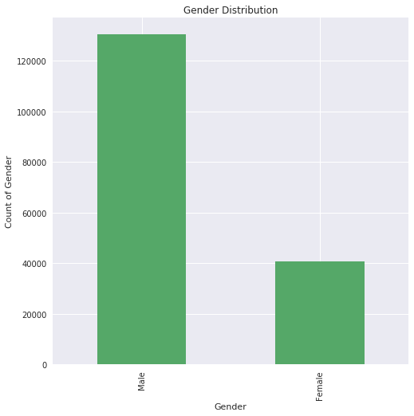

```python
gender_df = df[df['member_gender'].isin(['Male', 'Female'])]
gender = gender_df['member_gender'].value_counts()
gender.plot(kind = "bar", color=sns.color_palette()[1]);

plt.title("Gender Distribution")
plt.ylabel('Count of Gender')
plt.xlabel('Gender');
;
```

#### Subscriber Vs Customers (Casual Riders)

There are more subscribers than casual riders as subscribers make up 89.2% of riders, while customers who are not on any subscription plan make up 10.8%.

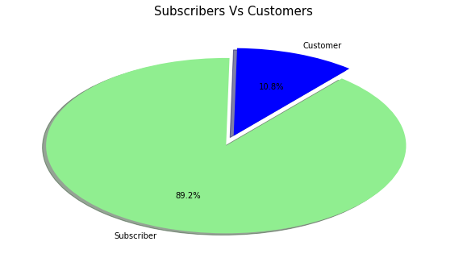

```python
customers = df.query('user_type == "Customer"')['bike_id'].count()
subscribers = df.query('user_type == "Subscriber"')['bike_id'].count()

customers_ = customers/df['bike_id'].count()
subscribers_ = subscribers/df['bike_id'].count()

plt.figure(figsize = [10, 5])

labels = ['Customer', 'Subscriber']
sizes = [customers_, subscribers_]
colors = ['#0000FF', '#90ee90']
explode = (0, 0.12)

plt.pie(sizes, explode=explode, labels=labels, colors = colors,
        autopct='%1.1f%%', shadow=True, startangle=50);
#plt.axis('equal')
plt.title('Subscribers Vs Customers', y=1.03, fontsize=15);
```

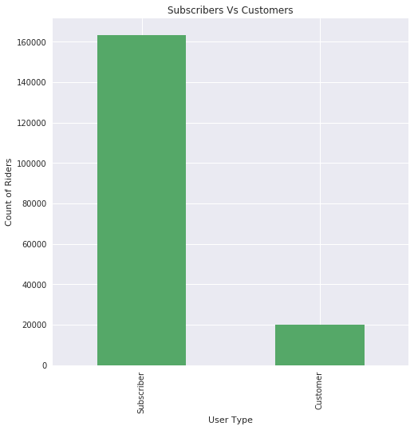

```python
df['user_type'].value_counts().plot(kind = "bar", color=sns.color_palette()[1]);

plt.title("Subscribers Vs Customers")
plt.ylabel('Count of Riders')
plt.xlabel('User Type');
```

#### Age distribution of riders

In exploring the age distribution of the bike riders, the seaborn violin plot and the histogram will be used.  
As the chart visualizations below shows, it is not surprising that the riders are mostly young people between the ages of 20 and 40 years

```
''
```

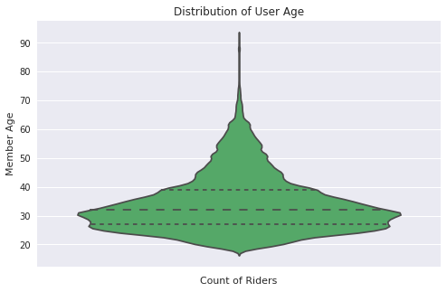

```python
# Investigate User Age distribution
df_age = df[df['member_age'] != 0]
df_age = df_age[df_age['member_age'] <= 95]
plt.figure(figsize=(8, 5))
sns.violinplot(df_age.member_age, inner='quartile', orient='v', saturation=1.5, color=sns.color_palette()[1])
plt.title('Distribution of User Age')
plt.ylabel('Member Age')
plt.xlabel('Count of Riders');
;
```

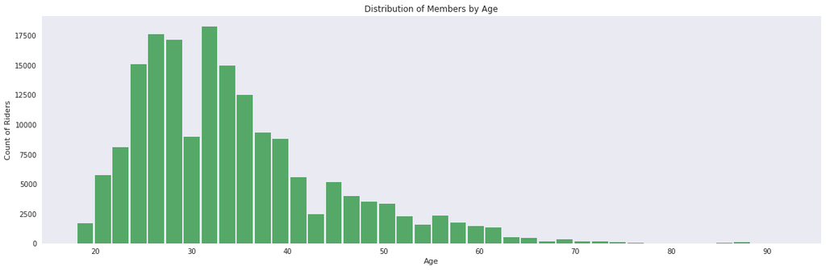

```python
ax = df_age.hist(column='member_age', bins=40, grid=False, figsize=(20,6), color=sns.color_palette()[1], zorder=2, rwidth=0.9)
ax = ax[0]
for x in ax:
    x.spines['right'].set_visible(False)
    x.spines['top'].set_visible(False)
    x.spines['left'].set_visible(False)
    x.set_title("Distribution of Members by Age")
    plt.ylabel('Count of Riders')
    plt.xlabel('Age');
```

#### Riders' length of trip

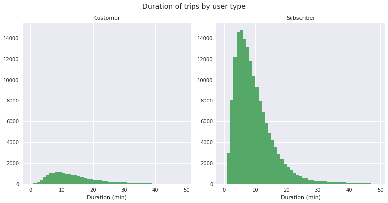

```python
sns.set(rc={'figure.figsize':(8,8
                             )})
x = sns.FacetGrid(df, col="user_type", margin_titles=True, size=5.5)
bin_edges = np.arange(0, 50,1)
x.map(plt.hist, "duration_mins", color=sns.color_palette()[1], bins=bin_edges)
x.set_axis_labels("Duration (min)")
x.set_titles(col_template = '{col_name}')
x.fig.suptitle('Duration of trips by user type', y=1.03, fontsize=14);
```

#### Trips by start time (hours)

What time of the day do people make the most trips? Analysis shows that as expected, riders have two peak periods; morning (between 7am and 9am) and evening (between 4pm and 7pm).

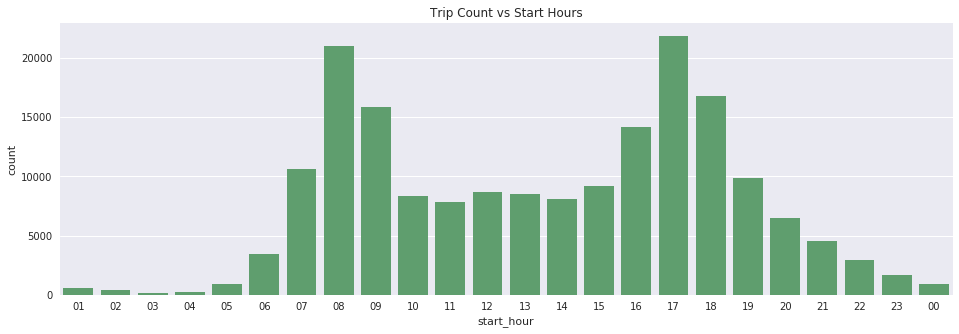

```python
# Trips by start time (hours)
plt.figure(figsize=(16, 5))
plt.title('Trip Count vs Start Hours')
x = sns.countplot(data=df, x='start_hour', color=sns.color_palette()[1]);
```

#### Trips by Weekend vs Weekday hours

We've seen most trips take place in the mornings and evenings. Delving deeper, how does this play out in the weekdays against weekends where there is expected to be vairiations in the daily commitment hours.  
The analysis shows that as expected, riders make rides during weekends between morning and afternoon, with peak hours at mid-day. This is contrary to weekdays that have two peak periods; morning (between 7am and 9am) and evening (between 4pm and 7pm).

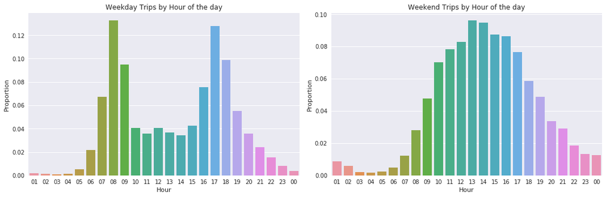

```python
df['weekday'] = df['start_time'].dt.weekday
plt.figure(figsize=(15,5))

plt.subplot(121)
weekday = df.query('weekday not in (5,6)')
weekday_hours = weekday.start_hour.value_counts(normalize=True)
sns.barplot(x= weekday_hours.keys(), y= weekday_hours.values)

plt.title('Weekday Trips by Hour of the day')
plt.ylabel('Proportion')
plt.xlabel('Hour');

plt.subplot(122)
weekend = df.query('weekday in (5,6)')
weekend_hours = weekend.start_hour.value_counts(normalize=True)
sns.barplot(x= weekend_hours.keys(), y= weekend_hours.values)

plt.title('Weekend Trips by Hour of the day')
plt.ylabel('Proportion')
plt.xlabel('Hour');

plt.tight_layout()
```

#### Bike Rides by Weekdays

We have seen the times most riders prefer to make a trip, and how this is reflected by weekdays and weekends.  
Further breaking down the analysis of bike ride behaviours of Customers and Subscribers, we will now explore which days of the week riders make the most rides.

As shown in the below graph, most bike rides suprisingly take place during the weekdays, with Thursdays at peak. Weekends (saturdays and sundays) experience the lowest rides. Maybe people prefer some family time.

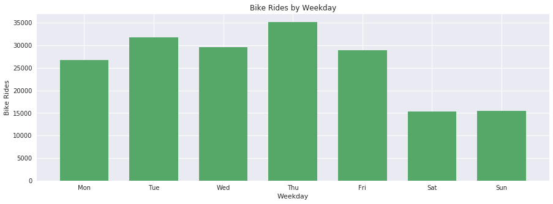

```python
# Bike Rides by Weekdays

plt.figure(figsize=[15,5])
bin_edges = np.arange(-0.5, 7, 1)
plt.hist(data = df, x = 'weekday', bins = bin_edges, rwidth = 0.7, color=sns.color_palette()[1])
plt.xticks(np.arange(0, 7, 1), ['Mon', 'Tue', 'Wed', 'Thu', 'Fri', 'Sat', 'Sun'])
plt.xlabel('Weekday')
plt.ylabel('Bike Rides')
plt.title("Bike Rides by Weekday");
```

### Distributions of the variables of interest

My interest was in the age distribution of the riders, and also their riding beheaviours. As expected, younger people took the most rides.  
Also, rides were carried out mostly in the mornings and evenings.  
A surprising observation however was the pattern of weekends. The weekends had fewer rides than weekdays, and the peak time of the day people take rides on weekends was at mid-day towards afternoon.  
Some extra columns were added; age, weekday, hours. Some transformations were also done, like correctly changing data types.

### Unusual distributions

The age column had unusual values, like 0, 120. These were excluded from analysis that had to determine age distribution so as to avoid misinterpretaion of data.

## Bivariate Exploration

It has been insightful exploring the distribution of some interesting variables. Now, we are delving deeper by examining the relationship between these variables.  
The variables which were earlier discussed, and will now be further examined are the:

1. user_type
2. member_gender
3. duration_mins
4. member_age
5. weekday
6. start_hour

To make the analysis easier to navigate and clean, the variables of interest will be aligned to a single table, `df_bivar`

```python
# define variables of interest, and create a new dataframe for this data
bivar_variables = ['user_type', 'member_gender','duration_mins', 'member_age', 'weekday','start_hour']

df_bivar = df[bivar_variables]
df_bivar['user_type'] = df_bivar['user_type'].replace(['Subscriber'],0)
df_bivar['user_type'] = df_bivar['user_type'].replace(['Customer'],1)
df_bivar['member_gender'] = df_bivar['member_gender'].replace(['Male'],0)
df_bivar['member_gender'] = df_bivar['member_gender'].replace(['Female', 'Other'],1)
df_bivar['start_hour'] = df_bivar['start_hour'].astype(int)
```

#### Pearson Correlation

A correlation Heatmap will be used to analyze the correlation between the variables. How do the vairiable relate to each other, and if there's a relationship, is it a weak or strong one

```python
# Correlation between the variables

df_bivar.corr()
```

|  | user_type | member_gender | duration_mins | member_age | weekday | start_hour |
| --- | --- | --- | --- | --- | --- | --- |
| user_type | 1.000000 | 0.101386 | 0.137211 | -0.128797 | 0.083482 | 0.013581 |
| member_gender | 0.101386 | 1.000000 | 0.046899 | -0.232569 | 0.017468 | -0.022292 |
| duration_mins | 0.137211 | 0.046899 | 1.000000 | -0.028344 | 0.033669 | 0.006638 |
| member_age | -0.128797 | -0.232569 | -0.028344 | 1.000000 | -0.045492 | -0.052164 |
| weekday | 0.083482 | 0.017468 | 0.033669 | -0.045492 | 1.000000 | 0.021129 |
| start_hour | 0.013581 | -0.022292 | 0.006638 | -0.052164 | 0.021129 | 1.000000 |

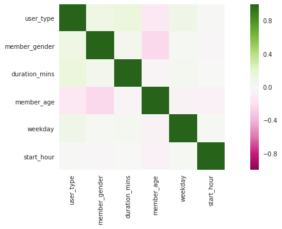

```python
# Pearson Correlation Heatmap
plt.figure(figsize=[15,5])
sns.heatmap(df_bivar.corr(), vmin=-1, vmax=1, cmap="PiYG", square=True);
```

All around the variables, there is a very weak correlation between the variables.  
Only `member_age` has a -0.23 correlation with `member_gender`. The `user_type` and `duration_mins` shows a positive correlation of 0.13 which might imply certain usertype (subscribers/customers) spend more time taking rides than the other usertype.

#### Relationship between Duration and Age of Riders

It is natural to suppose the younger you are, the longer your ride should be. But what does the data say? Is there a correlation between these two, and in what direction is it?

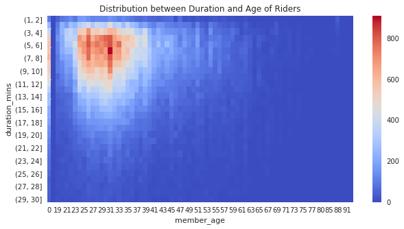

```python
# Plot Heatmap for the relationship between Duration and Age of Riders
df_bivar_dur = df_bivar.query('member_age <95 & duration_mins < 30')

plt.figure(figsize=[10,5])
bin_duration = pd.cut(df_bivar_dur.duration_mins, bins=range(0,61))
sns.heatmap(df_bivar_dur.pivot_table(index=bin_duration, columns=df_bivar_dur.member_age,
                                     aggfunc='count', fill_value=0).member_gender, vmin=0,
           cmap="coolwarm");
plt.title('Distribution between Duration and Age of Riders');
```

The Heatmap shows that riders between the ages of 23 and 35 take the most rides. Also revealing is that these rides by this age group mostly had a duration of between 3 to 10 mins.

Longer rides between 11 minutes and 20 minutes were taken by those within the age group of 29 and 39.

#### Relationship between the age of the bike riders, and the hour of the day

In the univariate analysis, we explored the hours of preference of riders, and how this differs with day of the week.  
However, do certain age group prefer to take their rides in certain hour(s) of the day?  
This we will find out by plotting a heatmap that shows the rlationship between the age of the bike riders, and the hour of the day.

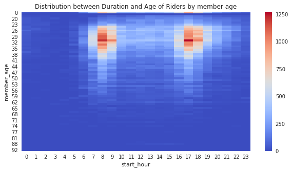

```python
# Plot Heatmap for the relationship between the age of the bike riders, and the hour of the day
plt.figure(figsize=[10,5])
sns.heatmap(df_bivar_dur.pivot_table(index=df_bivar_dur.member_age,
                                     columns=df_bivar_dur.start_hour, aggfunc='count', fill_value=0).member_gender,
            vmin=0,cmap="coolwarm");
plt.title('Distribution between Duration and Age of Riders by member age');
```

Though the younger ones take the most rides, there is no correlation between the age of the riders and the hour of the day when the trip took place.

### Interesting relationships observed

1. A surprising observation however was the pattern of weekends. The weekends had fewer rides than weekdays, and the peak time of the day people take rides on weekends was at mid-day towards afternoon.

## Multivariate Exploration

Having explored the data and examined relationships between variables in the dataset, the multivariate exploration will allow an even more extensive analysis into the relationship between these variables. We will be exploring same variables analyzed in the bivariate exploration:

1. user_type
2. member_gender
3. duration_mins
4. member_age
5. weekday
6. start_hour

#### Relationship between the duration, user types, and the gender of the Riders

We are going to look at how these three variables relate to each other using a violin plot

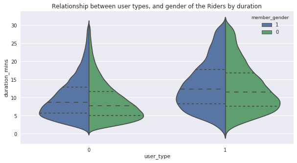

```python
# Relationship between the duration, user types, and the gender of the Riders

plt.figure(figsize=[10,5])
sns.violinplot(data=df_bivar_dur, y='duration_mins', x='user_type', hue='member_gender', split=True, orient='v', inner='quartile',
              hue_order=[1,0]);
plt.title('Relationship between user types, and gender of the Riders by duration');
```

Customers (Casual riders) have only few minutes of ride, compared to the subscribers that have access to at least 45 minutes of ride. However, customers had longer duration of minutes compared to the subscribers whose duration was generally shorter.

Customers might want to maximise the opportunity they have to ride, and might be tourists taking leisure rides. This might be why the rides are longer than subscribers.

Evaluating the relationship between gender and ride duration, there seems to be no difference, as both genders perform as well as the other.

#### Relationsip between age and subscribers/customers by Duration

This exploration will split user types into subscribers and customers, and find out how each relate with age and duration of trip.

```python
subscriber_only = df_bivar.query('user_type == 0 & duration_mins < 30')
customer_only = df_bivar.query('user_type == 1 & duration_mins < 30')
```

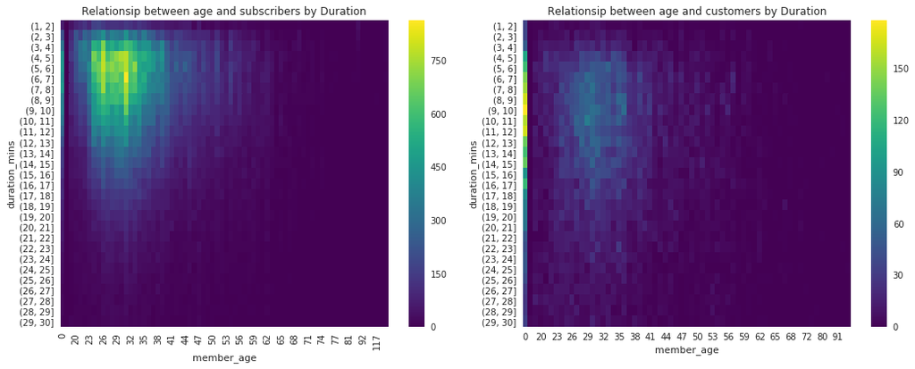

```python
# Trip duration vs User age - count vs Subscriber
plt.figure(figsize=[15,6])

plt.subplot(121)
bin_duration = pd.cut(subscriber_only.duration_mins, bins=range(0,61))
sns.heatmap(subscriber_only.pivot_table(index=bin_duration, columns=subscriber_only.member_age, aggfunc='count',
                                fill_value=0).member_gender, vmin=0,cmap='viridis');
plt.title('Relationsip between age and subscribers by Duration');

plt.subplot(122)
bin_duration = pd.cut(customer_only.duration_mins, bins=range(0,61))
sns.heatmap(customer_only.pivot_table(index=bin_duration, columns=customer_only.member_age, aggfunc='count',
                                fill_value=0).member_gender, vmin=0,cmap='viridis');
plt.title('Relationsip between age and customers by Duration');

plt.tight_layout()
```

The ride pattern between subscribers and customers differ as revealed in this analysis.

The **Subscribers** are of younger age and they made shorter duration trips. Their age ranged between 25 and 30 years old, and they mostly did 3 to 10 minutes rides.

In contrast, the **customers** who are casual riders were mostly between the ages of 29 and 39, and did as much as 20 minutes ride duration and even beyond.

### Relationships observed in the multivariate investigation

I expected the multivariate analysis to strengthen the weak correlation observed between the variables as observed in the bivariate analysis. There was however no strong relationship between the variables. Variables that showed some sort of weak correlation could however change position if we had a larger dataset.

## Conclusions

This analysis was an interesting one, as this tempts me into picking up a bike and make a very long trip. The data is about a February 2019 information about individual rides made in a bike-sharing system covering the greater San Francisco Bay area.

No significant relationship was observed between the variables covered, and number of rides differ by day of the week, and by age of the riders.